# barplot

hou

2018/9/19

本文介绍如何画条形图，或者叫柱状图、堆砌图。

## Plot

```r
summary(cars)
```

```
##      speed           dist
##  Min.   : 4.0   Min.   :  2.00
##  1st Qu.:12.0   1st Qu.: 26.00
##  Median :15.0   Median : 36.00
##  Mean   :15.4   Mean   : 42.98
##  3rd Qu.:19.0   3rd Qu.: 56.00
##  Max.   :25.0   Max.   :120.00
```

## ggplot2

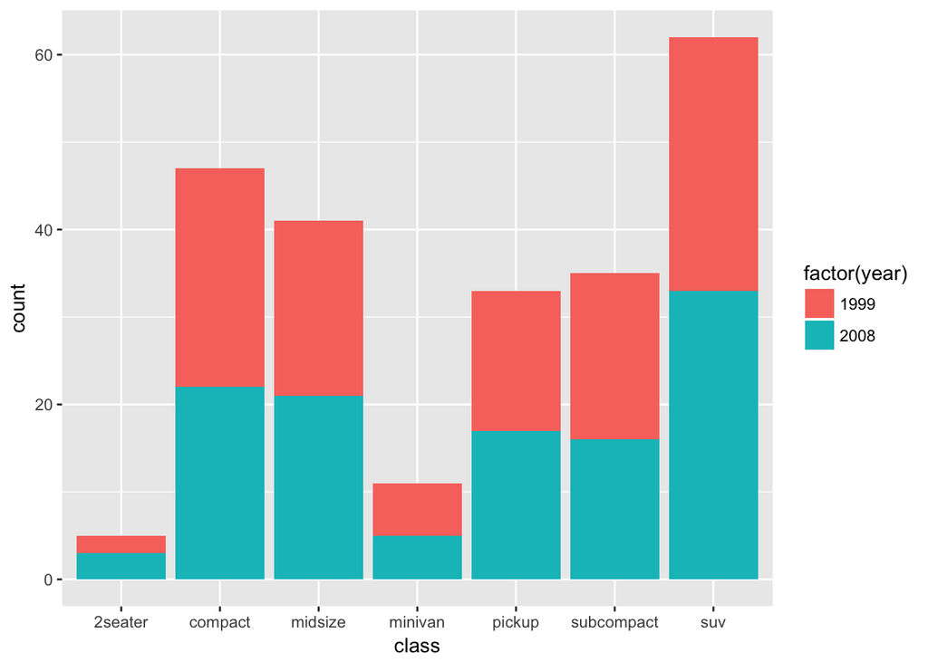

### 2.1 条形图分离

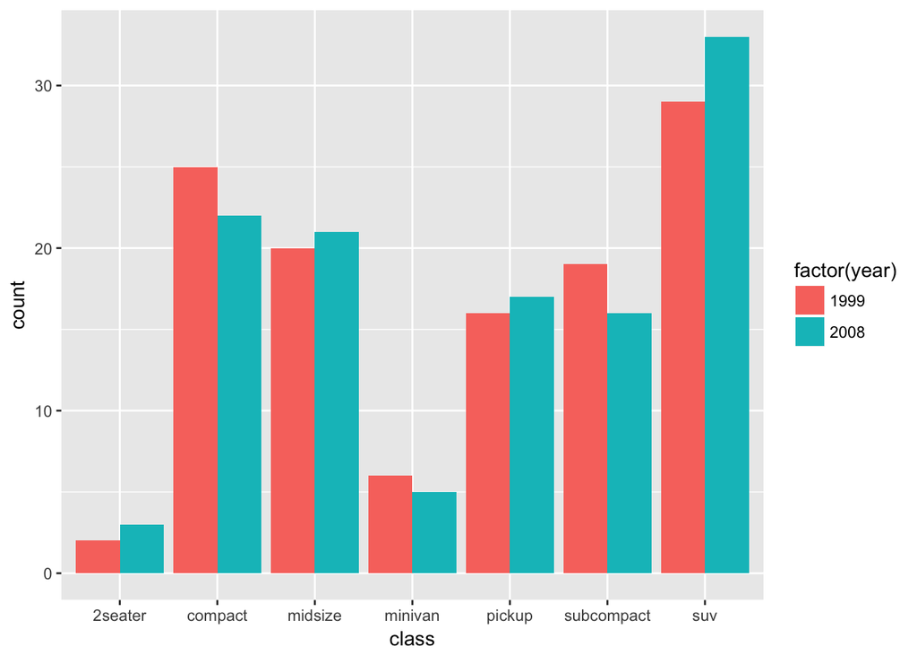

```r
library(ggplot2)
p <- ggplot(mpg, aes(x=class, fill=factor(year)))
p + geom_bar(position = 'dodge')
```

在`geom_bar`中添加参数`position = 'dodge'`，可以把原本堆叠在一起的条形图分离。 而`position = 'stack'`则是堆叠的条形图效果。

### 2.2 百分比条形图

把 `position参数`改为`position = 'fill'`，则可以画出两个不同年份各类别车数量的相互占比情况。如下图，纵坐标范围为 0~1，代表百分比从0~100%。根据百分比条形图可以很方便的看出两个年份之间的占比。

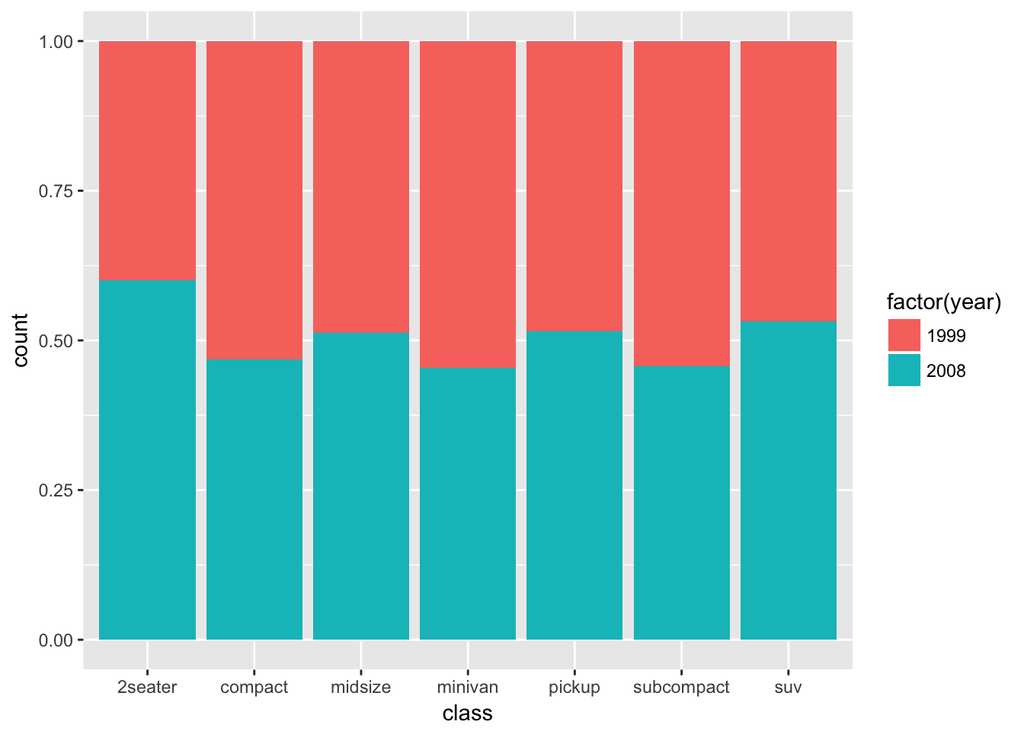

```r
library(ggplot2)
p <- ggplot(mpg, aes(x=class, fill=factor(year)))
p + geom_bar(position = 'fill')
```

### 2.3 改变颜色

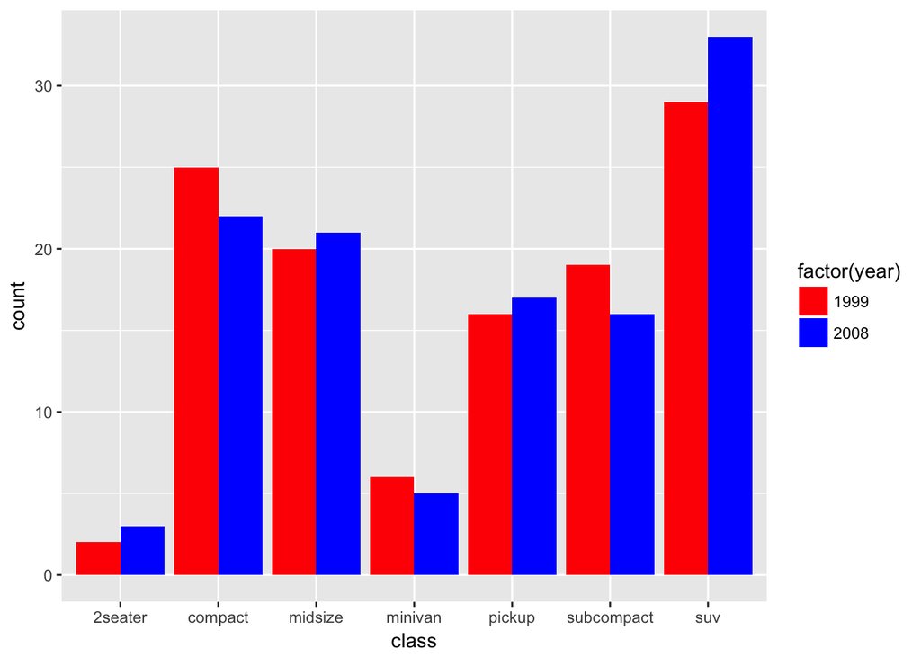

```r
library(ggplot2)
p <- ggplot(mpg, aes(x=class, fill=factor(year)))
p + geom_bar(position = 'dodge') + scale_fill_manual(values = c("red","blue"))
```

### 2.4 调整条形图粗细

在`geom_bar`中添加参数`width`。

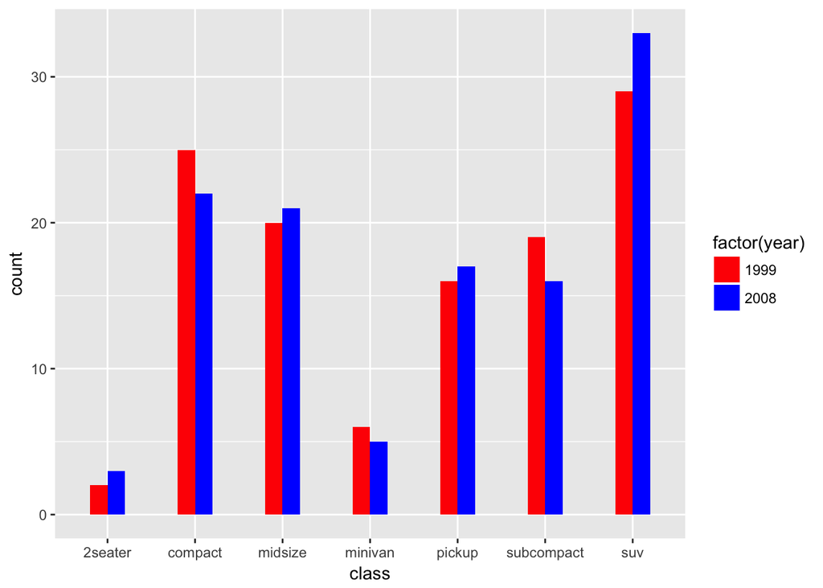

```r
library(ggplot2)
p <- ggplot(mpg, aes(x=class, fill=factor(year)))
p + geom_bar(position = 'dodge', width = 0.4) + scale_fill_manual(values = c("red","blue"))
```

### 2.5 添加数据显示

`geom_text(mapping = aes(label = ))` 如果添加的条形是`stack`或者`dodge`，则需要在geom_text()中添加`position`参数。 如果是堆叠图， 则`position = position_stack()`； 如果是离散的条形图，则`position = position_dodge(width = )`

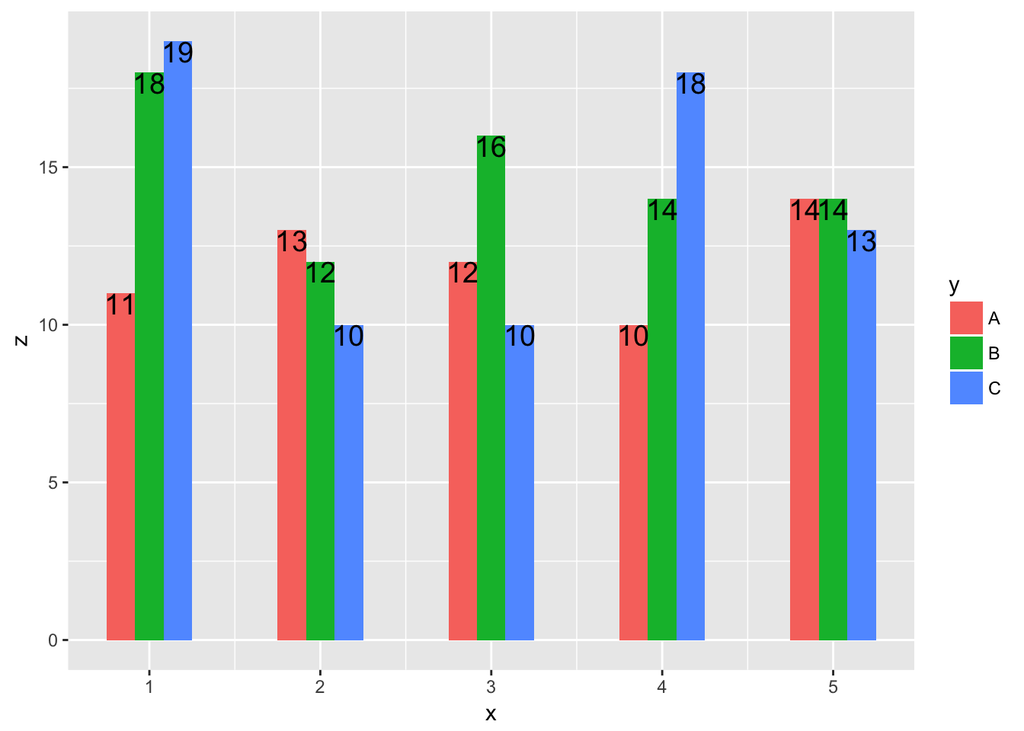

```r
library(ggplot2)
x <- rep(1:5,each = 3)
y <- rep(c("A","B","C"),times = 5)
set.seed(12)
z <- round(runif(min = 10,max = 20,n = 15))
df <- data.frame(x = x,y = y,z = z)
ggplot(data = df, mapping = aes(x = x, y = z, fill = y)) + geom_bar(width = 0.5,stat
= 'identity', position = 'dodge') + geom_text(mapping = aes(label = z),
size = 5, colour = 'black', vjust = 1, hjust = .5, position = position_dodge(width = 0.5))
```